# 視覺化

## 郭耀仁

## 課程內容

- 關於視覺化
- Matplotlib
  - 向 Matplotlib 說嗨
  - 圖、子圖
  - 不同的圖形
- Seaborn
- Future of Visualization Tools

## 視覺化的力量

- [Hans Rosling](https://www.youtube.com/watch?v=jbkSRLYSojo)

> He rose to international celebrity status after producing a [Ted Talk](https://www.ted.com/talks/hans_rosling_shows_the_best_stats_you_ve_ever_seen?language=zh-tw) in which he promoted the use of data to explore development issues. [Hans Rosling - Wikipedia](https://en.wikipedia.org/wiki/Hans_Rosling)

## 視覺化的力量（2）

- 200 年
- 200+ 個國家
- 120,000+ 列資料
- 4 分鐘
- 1 個視覺化

## 視覺化的力量（3）

- 反觀？

[figure not shown]

## 視覺化的力量（4）

- 視覺化在資料科學常見的應用場景：
  - 提升溝通效率（Business Intelligence、Infographics）
  - 幫助暸解模型、演算法（*）

## Matplotlib

- Python 基礎的繪圖套件

```
%matplotlib inline # 讓圖能夠在 Notebook 中顯示，不一定需要
import matplotlib.pyplot as plt
```

## Matplotlib（2）

- 向 Matplotlib 說嗨
- 圖、子圖
- 不同的圖形

## 向 Matplotlib 說嗨

- `plot()` 函數
- 全部採用預設值

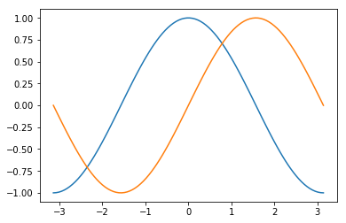

```python
import numpy as np
import matplotlib.pyplot as plt

# 建立 data
x = np.linspace(-np.pi, np.pi, 100)
cos_x, sin_x = np.cos(x), np.sin(x)

# 作圖
plt.plot(x, cos_x)
plt.plot(x, sin_x)

# 顯示
plt.show()
```

## 向 Matplotlib 說嗨（2）

- 試著更換線的[顏色](https://matplotlib.org/api/colors_api.html#matplotlib.colors.LinearSegmentedColormap)、寬度與[樣式](https://matplotlib.org/devdocs/gallery/lines_bars_and_markers/line_styles_reference.html)

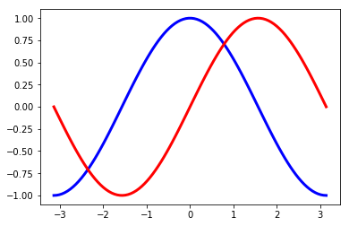

```python
import numpy as np
import matplotlib.pyplot as plt

# 建立 data
x = np.linspace(-np.pi, np.pi, 100)
cos_x, sin_x = np.cos(x), np.sin(x)

# 作圖
plt.plot(x, cos_x, color = "blue", linewidth = 3, linestyle = "-")
plt.plot(x, sin_x, color = "red", linewidth = 3, linestyle = "-")

# 顯示
plt.show()
```

## 向 Matplotlib 說嗨（3）

- 試著更換 X 軸與 Y 軸的範圍

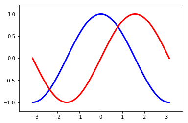

```python
import numpy as np
import matplotlib.pyplot as plt

# 建立 data
x = np.linspace(-np.pi, np.pi, 100)
cos_x, sin_x = np.cos(x), np.sin(x)

# 作圖
plt.plot(x, cos_x, color = "blue", linewidth = 3, linestyle = "-")
plt.plot(x, sin_x, color = "red", linewidth = 3, linestyle = "-")
plt.xlim(x.min()*1.2, x.max()*1.2)
plt.ylim(cos_x.min()*1.2, cos_x.max()*1.2)

# 顯示
plt.show()
```

## 向 Matplotlib 說嗨（4）

- 試著更換座標軸刻度

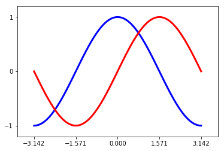

```python
import numpy as np
import matplotlib.pyplot as plt

# 建立 data
x = np.linspace(-np.pi, np.pi, 100)
cos_x, sin_x = np.cos(x), np.sin(x)

# 作圖
plt.plot(x, cos_x, color = "blue", linewidth = 3, linestyle = "-")
plt.plot(x, sin_x, color = "red", linewidth = 3, linestyle = "-")
plt.xlim(x.min()*1.2, x.max()*1.2)
plt.ylim(cos_x.min()*1.2, cos_x.max()*1.2)
plt.xticks([-np.pi, -np.pi/2, 0, np.pi/2, np.pi])
plt.yticks([-1, 0, 1])

# 顯示
plt.show()
```

## 向 Matplotlib 說嗨（5）

- 試著更換座標軸刻度的顯示標籤
- `matplotlib.pyplot` 的標籤支援 LaTeX/Mathematics 的語法

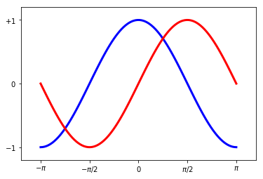

```python
import numpy as np
import matplotlib.pyplot as plt

# 建立 data
x = np.linspace(-np.pi, np.pi, 100)
cos_x, sin_x = np.cos(x), np.sin(x)

# 作圖
plt.plot(x, cos_x, color = "blue", linewidth = 3, linestyle = "-")
plt.plot(x, sin_x, color = "red", linewidth = 3, linestyle = "-")
plt.xlim(x.min()*1.2, x.max()*1.2)
plt.ylim(cos_x.min()*1.2, cos_x.max()*1.2)
plt.xticks([-np.pi, -np.pi/2, 0, np.pi/2, np.pi], ["$-\pi$", "$-\pi/2$", "$0$", "$\pi/2$", "$\pi$"])
plt.yticks([-1, 0, 1], ["$-1$", "$0$", "$+1$"])

# 顯示
plt.show()
```

## 向 Matplotlib 說嗨（6）

- 試著將圖的外框（spine）移動
  - 隱藏一個水平、一個垂直
  - 將剩餘的兩個移動至原點

```python
import numpy as np
import matplotlib.pyplot as plt

# 建立 data
x = np.linspace(-np.pi, np.pi, 100)
cos_x, sin_x = np.cos(x), np.sin(x)

# 作圖
plt.plot(x, cos_x, color = "blue", linewidth = 3, linestyle = "-")
plt.plot(x, sin_x, color = "red", linewidth = 3, linestyle = "-")
plt.xlim(x.min()*1.2, x.max()*1.2)
plt.ylim(cos_x.min()*1.2, cos_x.max()*1.2)
plt.xticks([-np.pi, -np.pi/2, 0, np.pi/2, np.pi], ["$-\pi$", "$-\pi/2$", "$0$", "$\pi/2$", "$\pi$"])
plt.yticks([-1, 0, 1], ["$-1$", "$0$", "$+1$"])
ax = plt.gca() # get current axes
ax.spines['right'].set_color('none')
ax.spines['top'].set_color('none')
ax.spines['bottom'].set_position(('data', 0))
ax.spines['left'].set_position(('data', 0))
```

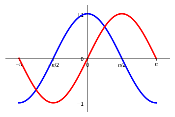

```python
# 顯示
plt.show()
```

## 向 Matplotlib 說嗨（7）

- 增加圖例

```python
import numpy as np
import matplotlib.pyplot as plt

# 建立 data
x = np.linspace(-np.pi, np.pi, 100)
cos_x, sin_x = np.cos(x), np.sin(x)

# 作圖
plt.plot(x, cos_x, color = "blue", linewidth = 3, linestyle = "-", label = "cos(x)")
plt.plot(x, sin_x, color = "red", linewidth = 3, linestyle = "-", label = "sin(x)")
plt.xlim(x.min()*1.2, x.max()*1.2)
plt.ylim(cos_x.min()*1.2, cos_x.max()*1.2)
plt.xticks([-np.pi, -np.pi/2, 0, np.pi/2, np.pi], ["$-\pi$", "$-\pi/2$", "$0$", "$\pi/2$", "$\pi$"])
plt.yticks([-1, 0, 1], ["$-1$", "$0$", "$+1$"])
ax = plt.gca() # get current axes
ax.spines['right'].set_color('none')
ax.spines['top'].set_color('none')
ax.spines['bottom'].set_position(('data', 0))
ax.spines['left'].set_position(('data', 0))
plt.legend(loc = 'upper left', frameon = False)
```

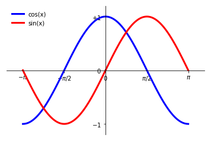

```python
# 顯示
plt.show()
```

## 向 Matplotlib 說嗨（8）

- 增加文字（annotation）

```python
import numpy as np
import matplotlib.pyplot as plt

# 建立 data
x = np.linspace(-np.pi, np.pi, 100)
cos_x, sin_x = np.cos(x), np.sin(x)

# 作圖
plt.plot(x, cos_x, color = "blue", linewidth = 3, linestyle = "-", label = "cos(x)")
plt.plot(x, sin_x, color = "red", linewidth = 3, linestyle = "-", label = "sin(x)")
plt.xlim(x.min()*1.2, x.max()*1.2)
plt.ylim(cos_x.min()*1.2, cos_x.max()*1.2)
plt.xticks([-np.pi, -np.pi/2, 0, np.pi/2, np.pi], ["$-\pi$", "$-\pi/2$", "$0$", "$\pi/2$", "$\pi$"])
plt.yticks([-1, 0, 1], ["$-1$", "$0$", "$+1$"])
ax = plt.gca() # get current axes
ax.spines['right'].set_color('none')
ax.spines['top'].set_color('none')
ax.spines['bottom'].set_position(('data', 0))
ax.spines['left'].set_position(('data', 0))
plt.legend(loc = 'upper left', frameon = False)
# 增加標記點與線
t = 2 * np.pi / 3
plt.plot([t, t],[0, np.sin(t)], color = 'red', linewidth = 2, linestyle = "--")
plt.scatter(t, np.sin(t), s = 50, color ='red')
# 增加文字
plt.annotate(r'$\sin(\frac{2\pi}{3})=\frac{\sqrt{3}}{2}$',
             xy=(t, np.sin(t)), xycoords='data',
             xytext=(+10, +30), textcoords='offset points', fontsize=14,
             arrowprops=dict(arrowstyle="->"))
```

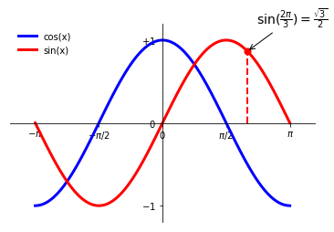

```python
# 顯示
plt.show()
```

## 向 Matplotlib 說嗨（9）

- 線圖最多的應用除了函數圖形，還有日期時間的資料
- 使用 `plot_date()` 方法

```python
import pandas as pd

url = "https://storage.googleapis.com/py_ml_datasets/aapl.csv"
aapl = pd.read_csv(url, index_col = 0, parse_dates = True)
print(aapl.index)
```

```
DatetimeIndex(['2017-06-28', '2017-06-29', '2017-06-30', '2017-07-03',
               '2017-07-05', '2017-07-06', '2017-07-07', '2017-07-10',
               '2017-07-11', '2017-07-12', '2017-07-13', '2017-07-14',
               '2017-07-17', '2017-07-18', '2017-07-19', '2017-07-20',
               '2017-07-21', '2017-07-24', '2017-07-25', '2017-07-26',
               '2017-07-27'],
              dtype='datetime64[ns]', name=u'Date', freq=None)
```

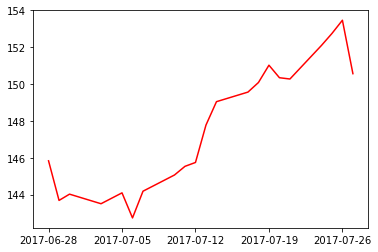

```python
# plt.plot_date()
import matplotlib.pyplot as plt

plt.plot_date(x = aapl.index, y = aapl.Close.values, fmt = "r-")
plt.show()
```

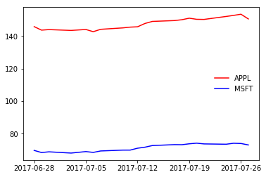

```python
# 增加 MSFT 的資料
url = "https://storage.googleapis.com/py_ml_datasets/msft.csv"
msft = pd.read_csv(url, index_col = 0, parse_dates = True)
plt.plot_date(x = aapl.index, y = aapl.Close.values, fmt = "r-", label = "APPL")
plt.plot_date(x = msft.index, y = msft.Close.values, fmt = "b-", label = "MSFT")
plt.legend(loc = 'center right', frameon = False)
plt.show()
```

## 向 Matplotlib 說嗨（10）

- `Pandas` 與 `Matplotlib` 本來都有 Yahoo Finance、Google Finance 的 API，但此刻都已經關閉
- [Quandl](https://www.quandl.com/tools/python) 是我用來擷取前面範例資料的 API

## 向 Matplotlib 說嗨（11）

- 練習作出下圖

```
# 增加文字
plt.annotate(r'$\cos(\frac{2\pi}{3})=-\frac{1}{2}$',
             xy=(t, np.cos(t)), xycoords = 'data',
             xytext=(-90, -50), textcoords = 'offset points', fontsize = 16,
             arrowprops=dict(arrowstyle="->"))
#...
```

[figure not shown]

## 圖、子圖

- `plt.figure()`
  - `figsize` 是圖片的長、寬（吋）
  - `dpi` 是圖片的解析度（Dots per inch）

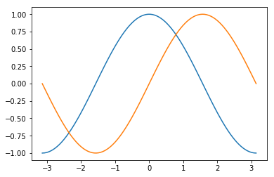

```python
import numpy as np
import matplotlib.pyplot as plt

# 建立 data
x = np.linspace(-np.pi, np.pi, 100)
cos_x, sin_x = np.cos(x), np.sin(x)

plt.figure() # 試著加入 figsize 與 dpi 參數調整看看
plt.plot(x, cos_x)
plt.plot(x, sin_x)
plt.show()
```

## 圖、子圖（2）

- `plt.subplot()`
  - 列數
  - 欄數
  - 第幾個圖
- 注意 `plt.subplot()` 的索引值要從 1 開始！

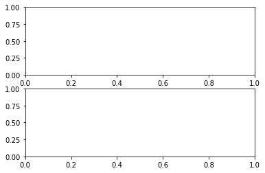

```python
import matplotlib.pyplot as plt

plt.subplot(2, 1, 1)
plt.subplot(2, 1, 2)

plt.show()
```

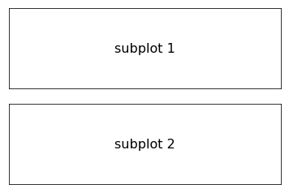

```python
import matplotlib.pyplot as plt

plt.subplot(2, 1, 1)
plt.xticks([]), plt.yticks([])
plt.text(0.5, 0.5, 'subplot 1', ha = 'center',va = 'center', size = 16)
plt.subplot(2, 1, 2)
plt.xticks([]), plt.yticks([])
plt.text(0.5, 0.5, 'subplot 2', ha = 'center',va = 'center', size = 16)

plt.show()
```

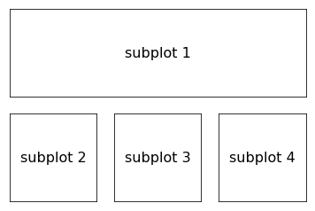

```python
import matplotlib.pyplot as plt

plt.subplot(2, 1 ,1)
plt.xticks([]), plt.yticks([])
plt.text(0.5, 0.5, 'subplot 1', ha = 'center',va = 'center', size = 16)

plt.subplot(2, 3, 4)
plt.xticks([]), plt.yticks([])
plt.text(0.5, 0.5, 'subplot 2', ha = 'center',va = 'center', size = 16)
plt.subplot(2, 3, 5)
plt.xticks([]), plt.yticks([])
plt.text(0.5, 0.5, 'subplot 3', ha = 'center',va = 'center', size = 16)
plt.subplot(2, 3, 6)
plt.xticks([]), plt.yticks([])
plt.text(0.5, 0.5, 'subplot 4', ha = 'center',va = 'center', size = 16)

plt.show()
```

## 圖、子圖（3）

- 運用 `gridspec` 進行更進階的子圖切割

```python
import matplotlib.pyplot as plt
import matplotlib.gridspec as gridspec

G = gridspec.GridSpec(3, 3)

plt.subplot(G[0, :])
plt.xticks([]), plt.yticks([])
plt.text(0.5, 0.5, 'subplot 1', ha = 'center',va = 'center', size = 18)

plt.subplot(G[1, :2])
plt.xticks([]), plt.yticks([])
plt.text(0.5, 0.5, 'subplot 2', ha = 'center',va = 'center', size = 18)

plt.subplot(G[1:, 2])
plt.xticks([]), plt.yticks([])
plt.text(0.5, 0.5, 'subplot 3', ha = 'center',va = 'center', size = 18)

plt.subplot(G[2, 0])
plt.xticks([]), plt.yticks([])
plt.text(0.5, 0.5, 'subplot 4', ha = 'center',va = 'center', size = 18)

plt.subplot(G[2, 1])
plt.xticks([]), plt.yticks([])
plt.text(0.5, 0.5, 'subplot 5', ha = 'center',va = 'center', size = 18)
```

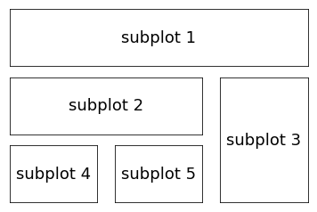

```python
plt.show()
```

## 圖、子圖（4）

- 練習作出下圖

```
x_1 = np.random.randn(1000) # for histogram
x_2 = np.arange(30) # for scatter
y_2 = np.arange(30) + 3 * np.random.rand(30) # for scatter
x_3 = np.random.randn(50).cumsum() # for plot
```

[figure not shown]

## 不同的圖形

| 繪圖函數 | 繪圖類型 |
| --- | --- |
| `plt.scatter()` | 散佈圖 scatter plot |
| `plt.bar()` | 長條圖 bar plot |
| `plt.hist()` | 直方圖 histogram |
| `plt.contour()` | 等高線圖 contour plot |
| `Axes3D()` | 3D 平面圖 |

## 不同的圖形（2）

- 散佈圖：呈現兩組數值的相關

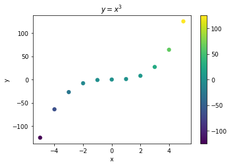

```python
# plt.scatter()
import matplotlib.pyplot as plt
import numpy as np

x = np.arange(-5, 6)
y = x**3
plt.scatter(x, y, c = y)
plt.xlabel("x")
plt.ylabel("y")
plt.title("$y = x^3$")
plt.colorbar()
plt.show()
```

## 不同的圖形（3）

- 長條圖：呈現類別變數的相異計數、不同類別的數值變數比較

```python
# plt.bar()
import numpy as np
import matplotlib.pyplot as plt

N = 5
ice_cream_sales = np.random.randint(50, 100, size = 5)
ind = np.arange(1, N + 1)
width = 0.5
plt.bar(ind, ice_cream_sales, width, facecolor = 'g')
plt.title('Ice cream sales by flavor')
plt.xticks(ind, ['Matcha', 'Chocolate', 'Vanilla', 'Coco', 'Strawberry']), plt.yticks([])
# Annotations
for x, y in zip(ind, ice_cream_sales):
    plt.text(x, y + 2, '%i' % y, ha = 'center', va = 'bottom')
plt.ylim(0, ice_cream_sales.max() * 1.2)
ax = plt.gca()
ax.spines['right'].set_color('none')
ax.spines['top'].set_color('none')
ax.spines['left'].set_color('none')
```

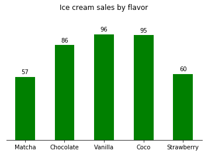

```python
plt.show()
```

## 不同的圖形（3）

- 直方圖：呈現數值變數的分佈

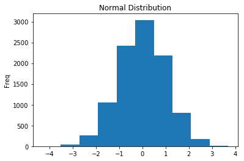

```python
# plt.hist()
import numpy as np
import matplotlib.pyplot as plt

data = np.random.normal(size = (10000, 1))
plt.hist(data)
plt.title('Normal Distribution')
plt.ylabel("Freq")
plt.show()
```

## 等高線圖

- `numpy.meshgrid()` 可以幫我們把一維數列分別往水平/垂直方向延伸為矩陣

```python
import numpy as np

u = np.arange(start = -5, stop = 5, step = 0.1)
x, y = np.meshgrid(u, u)
print x
print "\n"
print y
```

```
[[-5.  -4.9 -4.8 ...,  4.7  4.8  4.9]
 [-5.  -4.9 -4.8 ...,  4.7  4.8  4.9]
 [-5.  -4.9 -4.8 ...,  4.7  4.8  4.9]
 ...,
 [-5.  -4.9 -4.8 ...,  4.7  4.8  4.9]
 [-5.  -4.9 -4.8 ...,  4.7  4.8  4.9]
 [-5.  -4.9 -4.8 ...,  4.7  4.8  4.9]]


[[-5.  -5.  -5.  ..., -5.  -5.  -5. ]
 [-4.9 -4.9 -4.9 ..., -4.9 -4.9 -4.9]
 [-4.8 -4.8 -4.8 ..., -4.8 -4.8 -4.8]
 ...,
 [ 4.7  4.7  4.7 ...,  4.7  4.7  4.7]
 [ 4.8  4.8  4.8 ...,  4.8  4.8  4.8]
 [ 4.9  4.9  4.9 ...,  4.9  4.9  4.9]]
```

## 等高線圖（2）

- 等高線圖需要第三個維度：`z` 來表示高度（顏色）

```python
import numpy as np

u = np.arange(start = -5, stop = 5, step = 0.1)
x, y = np.meshgrid(u, u)
z = x**2 + y**2
print z
```

```
[[ 50.    49.01  48.04 ...,  47.09  48.04  49.01]
 [ 49.01  48.02  47.05 ...,  46.1   47.05  48.02]
 [ 48.04  47.05  46.08 ...,  45.13  46.08  47.05]
 ...,
 [ 47.09  46.1   45.13 ...,  44.18  45.13  46.1 ]
 [ 48.04  47.05  46.08 ...,  45.13  46.08  47.05]
 [ 49.01  48.02  47.05 ...,  46.1   47.05  48.02]]
```

## 等高線圖（3）

- `contour()` 是沒有填色的

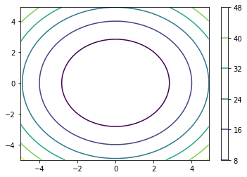

```python
import numpy as np

u = np.arange(start = -5, stop = 5, step = 0.1)
x, y = np.meshgrid(u, u)
z = x**2 + y**2
plt.contour(x, y, z)
plt.colorbar()
plt.show()
```

## 等高線圖（4）

- `contourf()` 是有填色的

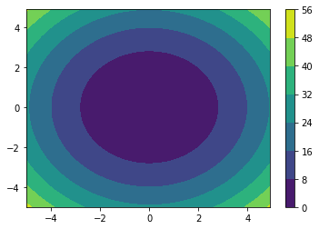

```python
import numpy as np
import matplotlib.pyplot as plt

u = np.arange(start = -5, stop = 5, step = 0.1)
x, y = np.meshgrid(u, u)
z = x**2 + y**2
cf = plt.contourf(x, y, z)
plt.colorbar(cf)
plt.show()
```

## 等高線圖（5）

- 為什麼要知道等高線圖怎麼畫？
  - 梯度遞減（Gradient Descent）的視覺化
  - 決策邊界（Decision Boundary）的視覺化

## 3D 平面圖

- 除了等高線圖，也可以使用 3D 平面圖視覺化梯度遞減
- `from mpl_toolkits.mplot3d import Axes3D`

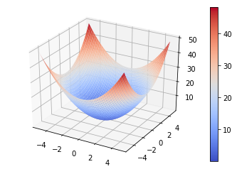

```python
import numpy as np
import matplotlib.pyplot as plt
from mpl_toolkits.mplot3d import Axes3D

fig = plt.figure()
ax = fig.add_subplot(111, projection='3d')

u = np.arange(start = -5, stop = 5, step = 0.1)
x, y = np.meshgrid(u, u)
z = x**2 + y**2
surf = ax.plot_surface(x, y, z, rstride = 2, cstride = 2, cmap = plt.cm.coolwarm, linewidth = 0.5, antialiased = True)
fig.colorbar(surf)
plt.show()
```

## 圖片視覺化

- 從 PNG 轉換為 ndarray
- 呈現 ndarray

## 圖片視覺化（2）

- 從 PNG 轉換為 ndarray
- 使用 `imread()` 方法

```python
import matplotlib.pyplot as plt
import matplotlib.image as mpimg
import numpy as np

url = "https://storage.googleapis.com/py_ml_images/luffy_wanted.png"
img = mpimg.imread(url)
print(type(img))
print(img.shape)
```

```
<type 'numpy.ndarray'>
(560, 384, 4)
```

[figure not shown]

```python
plt.imshow(img)
plt.show()
```

[figure not shown]

```python
plt.figure(figsize = (10, 6), dpi = 80)
for i in range(img.shape[-1]):
    plt.subplot(1, img.shape[-1], i + 1)
    lum_img = img[:, :, i]
    plt.imshow(lum_img)
plt.tight_layout()
plt.show()
```

[figure not shown]

```python
plt.imshow(img[: , :, 0], cmap = "hot")
plt.show()
```

## 圖片視覺化（3）

- 呈現 ndarray
- 使用 `imshow()` 方法

```python
from sklearn import datasets

digits = datasets.load_digits()
print(digits.images.shape)
print(digits.images[0].shape)
```

```
(1797, 8, 8)
(8, 8)
```

## 圖片視覺化（4）

- `cmap` 參數可以指定色階
- [colormaps](https://matplotlib.org/examples/color/colormaps_reference.html)

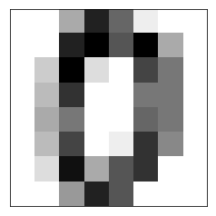

```python
from sklearn import datasets
import matplotlib.pyplot as plt

digits = datasets.load_digits()
plt.imshow(digits.images[0], cmap = "binary")
plt.xticks([]), plt.yticks([])
plt.show()
```

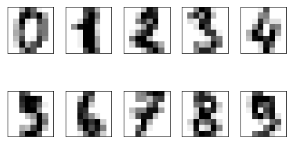

```python
# 看 10 張
from sklearn import datasets
import matplotlib.pyplot as plt

digits = datasets.load_digits()
for idx, val in enumerate(range(1, 11)):
    plt.subplot(2, 5, val)
    plt.imshow(digits.images[idx], cmap = "binary")
    plt.xticks([]), plt.yticks([])
plt.tight_layout()
plt.show()
```

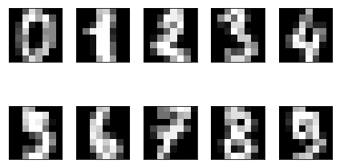

```python
# 看 10 張
# cmap 改用 "gray"

from sklearn import datasets
import matplotlib.pyplot as plt

digits = datasets.load_digits()
for idx, val in enumerate(range(1, 11)):
    plt.subplot(2, 5, val)
    plt.imshow(digits.images[idx], cmap = "gray")
    plt.xticks([]), plt.yticks([])
plt.tight_layout()
plt.show()
```

## 圖片視覺化（5）

- `interpolation` 參數可以指定內插補值法
- 讓圖片看起來不會一格一格
- [interpolation](https://matplotlib.org/examples/images_contours_and_fields/interpolation_methods.html)

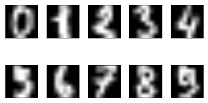

```python
# 看 10 張
# cmap 改用 "gray"
# 加上 interpolation 內插法 bilinear

from sklearn import datasets
import matplotlib.pyplot as plt

digits = datasets.load_digits()
for idx, val in enumerate(range(1, 11)):
    plt.subplot(2, 5, val)
    plt.imshow(digits.images[idx], cmap = "gray", interpolation = "bilinear")
    plt.xticks([]), plt.yticks([])
plt.tight_layout()
plt.show()
```

## Seaborn

- 以 matplotlib 為基礎建構的高階繪圖套件，
- 可以將它視為是 matplotlib 的補強
- 安裝指令：

```
conda install -c anaconda seaborn
```

## Seaborn（2）

- 散佈圖：`sns.jointplot()`

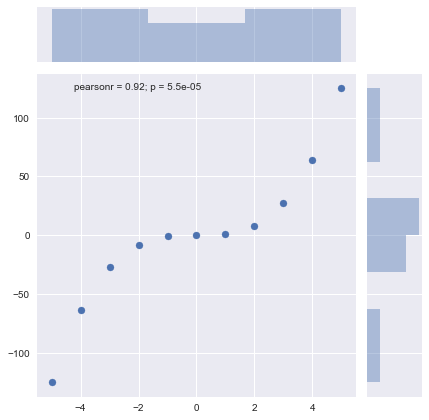

```python
import seaborn as sns
import pandas as pd
import matplotlib.pyplot as plt

x = np.arange(-5, 6)
y = x**3
sns.jointplot(x = x, y = y)
plt.show()
```

## Seaborn（3）

- 長條圖：`sns.barplot()`

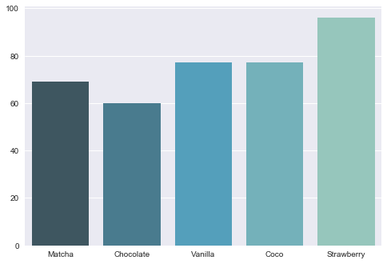

```python
import numpy as np
import matplotlib.pyplot as plt
import seaborn as sns

ice_cream_flavors = ['Matcha', 'Chocolate', 'Vanilla', 'Coco', 'Strawberry']
ice_cream_sales = np.random.randint(50, 100, size = 5)
sns.barplot(x = ice_cream_flavors, y = ice_cream_sales, palette="GnBu_d")
plt.show()
```

## Seaborn（4）

- 直方圖：`sns.distplot()`

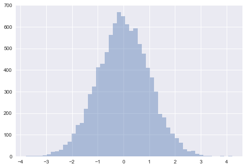

```python
# sns.distplot()
import numpy as np
import matplotlib.pyplot as plt
import seaborn as sns

data = np.random.normal(size = (10000, 1))
sns.distplot(data, kde = False)
plt.show()
```

## Future of Visualization Tools

Quoted from Wes McKinney:

> The Future of Visualization Tools?

> Visualizations built on web technologies (that is, JavaScript-based) appear to be the inevitable future. Doubtlessly you have used many different kinds of static or interactive visualizations built in Flash or JavaScript over the years. New toolkits (such as d3.js and its numerous off-shoot projects) for building such displays are appearing all the time. In contrast, development in non web-based visualization has slowed significantly in recent years. This holds true of Python as well as other data analysis and statistical computing environments like R.

## Future of Visualization Tools（2）

- Writing Python:
  - [Bokeh](http://bokeh.pydata.org/en/latest/)
  - [Plotly](https://plot.ly/python/)
- Writing JavaScript:
  - [d3.js](https://d3js.org/)

## 作業

- 自訂函數 `sign_fun()` 並且作圖（自由取一段 x 區間）

$$ sgn(x) = \begin{cases} -1 & \quad \text{if } x < 0\\ 0 & \quad \text{if } x = 0\\ 1 & \quad \text{if } x > 0\\ \end{cases} $$

- 自訂函數 `sigmoid_fun()` 並且作圖（自由取一段 x 區間）

$$S(x) = \frac{1}{1 + e^{-x}}$$

- 承前題，將前兩個函數畫在同一個函數圖（Optional）
- 承前題，利用 `subplot()` 將這兩個圖畫在 (1, 2) 的畫布上（Optional）

## 專題

- 整合您的 NumPy、Pandas、繪圖與 markdown 技巧
- 針對 https://storage.googleapis.com/py_ml_datasets/train.csv 進行探索性資料分析（Exploratory Data Analysis）